# Prediction of Astrological Objects: Star, Quasar, or Galaxy?

This project focuses on constructing several classification models to determine whether a given celestial object is a star, quasar, or galaxy. Initial steps include inspecting the given data and understanding each of the variables presented before cleaning and transforming the data into a form that will be suitable for model building. Using multiple different classification methods, the models will be tuned and compared across several scoring metrics including accuracy, f1-score, and run times.

The data used in this analysis was retreived from [Kaggle](https://www.kaggle.com/datasets/fedesoriano/stellar-classification-dataset-sdss17) which was originally extracted from the [Sloan Digital Sky Survey](https://classic.sdss.org/)

## Project Goal: Determine which model or models result in the most accurate classification in respect to every target class while taking into account the strengths and weaknesses of each model

**Techniques highlighted in this project:**

- Several multiclass classification methodologies
- Large dataset management
- Outlier detection
- Hyperparameter tuning
- Cross validation
- Feature selection

# Required Packages

```python
#Dataset Management
import numpy as np
import pandas as pd

#Plots
import seaborn as sns
import matplotlib.pyplot as plt

#Train-Test Split
from sklearn.model_selection import train_test_split

#Outlier Detection
from sklearn.neighbors import LocalOutlierFactor

#Feature Selection/Dimensionality Reduction
from sklearn.decomposition import PCA

#Standardization
from sklearn.preprocessing import StandardScaler

#Classification
from sklearn.pipeline import Pipeline
from sklearn import svm
from sklearn.linear_model import LogisticRegression
from sklearn.neighbors import KNeighborsClassifier
from sklearn.ensemble import RandomForestClassifier
from xgboost import XGBClassifier

#Classification Metrics
from sklearn import metrics
from sklearn.metrics import balanced_accuracy_score, precision_score, recall_score, f1_score
from sklearn.model_selection import StratifiedKFold, cross_validate, cross_val_score, GridSearchCV
from skopt import BayesSearchCV
import warnings
from skopt.space import Real, Categorical, Integer
from time import time
```

# Exploring the Data

```python
#Load Datset
df = pd.read_csv('star_classification.csv')
```

```python
#Map class variable inputs to 0,1,2
mapping = {'STAR':0, 'QSO':1, 'GALAXY':2}
df = df.replace({'class':mapping})
```

## Class Imbalance

Class imbalance can sometimes have a large affect on the predictive ability of a classifier. In certain cases, a classifier will tend to classify the most frequent class well while the smaller class or classes tend to be overlooked and perform worse. There are certain resampling techniques, such as SMOTE or Tomek-Links, that can be implemented to help balance the class sizes and remedy this. However, there are still several models that are able to handle class sizes with different proportion of available data. In this case, the class sizes will remain unchanged.

```
[Text(0.5, 1.0, 'Stellar Class Counts')]
```

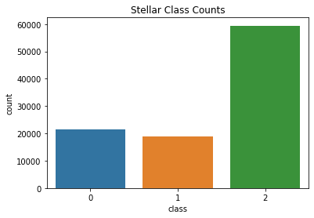

```python
#Generate countplot of each class size
sns.countplot(data=df,x='class').set(title='Stellar Class Counts')
```

## Dataframe Variables:

- `obj_ID`: Object identifier, the unique value that identifies the object in the image catalog used by the CAS
- `alpha`: Right Ascension angle (at J2000 epoch)
- `delta`: Declination angle (at J2000 epoch)
- `u`: Ultraviolet filter in the photometric system
- `g`: Green filter in the photometric system
- `r`: Red filter in the photometric system
- `i`: Near Infrared filter in the photometric system
- `z`: Infrared filter in the photometric system
- `run_ID`: Run Number used to identify the specific scan
- `rerun_ID`: Rerun Number to specify how the image was processed
- `cam_col`: Camera column to identify the scanline within the run
- `field_ID`: Field number to identify each field
- `spec_obj_ID`: Unique identifier used for identifying the interaction and emission of light (*Two objects with the same ID must have the same object class*)
- `class`: object class - a galaxy, star or quasar object
- `redshift`: redshift value based on the increase in wavelength
- `plate`: Aluminum plate identifier, identifies each plate in SDSS telescope
- `MJD`: Modified Julian Date, used to indicate when a given SDSS data was taken
- `fiber_ID`: Fiber identifier which identifies the fiber located in the plate hole that pointed the light at the focal plane in each observation

There are several variables included in the dataframe that pertain to how the SDSS stores data and not the celestial object themself which can be omitted.

```python
#Remove unnecessary variables
df = df.drop(['obj_ID','run_ID','rerun_ID','cam_col','field_ID','fiber_ID','MJD','spec_obj_ID'],axis=1)
```

# Preparing the Data

## Outlier Detection

Before beginning the more rigorous elements of building the classification models, outliers should be taken into account to avoid these instances from having an impact on the remaining analysis. Though the idea and definition of an outlier varies depending on the circumstances, there are methods that can be used to identify potential outliers. One such methodology is the **Local Outlier Factor** algorithm.

This algorithm works by calculating the local densities of a given data point and comparing it with respect to its nearest neighbors. Points that have substantially lower densities than that of their nearest neighbors are considered to be outliers. Removing outliers early before performing transformations or modeling can help improve the overall result of the finalized classifiers.

```python
#Remove outlier points using Local Outlier Factor method:
outlier_detect = LocalOutlierFactor(n_neighbors=316)
outlier_predict = outlier_detect.fit_predict(df)
outliers = pd.DataFrame(outlier_predict, columns=['LOF'])
flter = outliers['LOF'] == -1
outlier_indx = outliers[flter].index.tolist()
df.drop(outlier_indx, inplace=True)
df = df.reset_index(drop=True)
```

## Multicollinearity

Multicollinearity refers to the correlation between the input variables of a model. Some models require that the input variables have little to no correlation between them as base assumptions in order for the classifier to function properly and have interpretable results. A simple heatmap can be implemented to display if this is a concern in the given data.

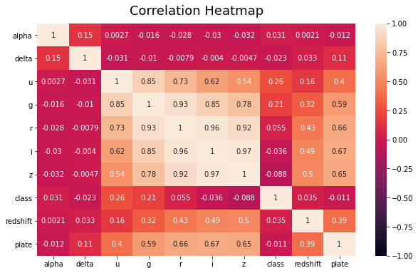

```python
plt.figure(figsize=(10, 6))
sns.heatmap(df.corr(), vmin=-1, vmax=1, annot=True).set_title('Correlation Heatmap', fontdict={'fontsize':18}, pad=12)
```

Using the correlation heatmap, it becomes clear that several of the variables, such as the light wavelengths variables, are highly correlated with one another. However from understanding the nature of the data and by having prior knowledge of celestial objects, it is known that light wavelengths are crucial to determining celestial bodies since they are one of the main sources for identifying these objects. With this in mind, an attempt to retain the information these variables contain should be made as well as the limitation these correlated variables may pose to certain modeling methodologies.

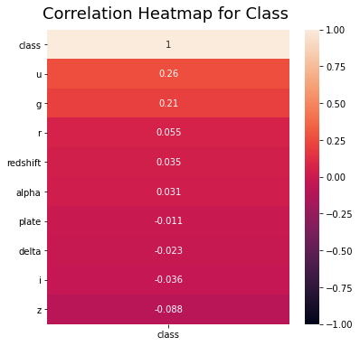

```python
plt.figure(figsize=(6, 6))
sns.heatmap(df.corr()[['class']].sort_values(by='class', ascending=False), vmin=-1, vmax=1,
            annot=True).set_title('Correlation Heatmap for Class ', fontdict={'fontsize':18}, pad=12)
```

Comparing the correlations of the input variables to the output classes, there seems little evidence of a direct linear relationship. However, there still may be non-linear relationships that may exist between these variables that are less easily identifiable and should be considered when determining an appropriate model.

## Train-Test Split

When generating a model, one way to determine if the model is doing a sufficient job at classifying this particular type of data is by attempting to classify it using a brand new set of data that hasn't been used in any phase of modeling. To acheive this, the data can be split into two sets: **One training set and one testing set**.

The larger training set will be used to build and tune the model using cross validation while the smaller testing set will remain unaltered until the final classifiers have been selected and final scoring metrics are being evaluated.

```python
#X/y split dataframe
X = df.drop(['class'],axis=1)
y = df['class']

columns = X.columns

#Split final dataframe into train/validation/test
X_train, X_test, y_train, y_test = train_test_split(X, y, test_size=0.2, random_state=2022, stratify=y)

#Reset index for X_train and y_train for cross validation indexing
X_train.reset_index(inplace=True)
X_train = X_train.drop('index',axis=1)
y_train = y_train.reset_index(drop=True)
print('Training Size: ', np.shape(X_train)[0])
print('Testing Size:  ', np.shape(X_test)[0])
```

```
Training Size:  73496
Testing Size:   18374
```

## Standardization

Though standardization is commonly implemented in data science to help bring all the variables into a common scale, it is especially important to perform it when implementing **principal component analysis** which will be done in the next step. Principal component analysis will be less accurate at retaining the original information if the variance levels between variables are substantially different.

```python
#Standardization: need to retain mean and s.d. for transforming validation & testing dataset
scaler = StandardScaler()
scaler.fit(X_train)

#Standardize training dataset
X_train_std = pd.DataFrame(scaler.transform(X_train),columns=columns)

#Standardize validation and testing datasets
X_test_std = pd.DataFrame(scaler.transform(X_test),columns=columns)
```

## Feature Selection

**Principal component analysis** can be used to reduce the overall number of features that will be taken as inputs into the model while retaining as much of the original information as possible. Another reason to transform the data using principal component analysis has to do with the multicollinearity problem stated earlier. PCA will retain much of the original information while returning new variables with little to no correlation between them which allows for the use of a wider array of modeling options.

```python
#PCA transform training dataset
pca = PCA(n_components=5)
X_train_pca = pd.DataFrame(pca.fit_transform(X_train_std),columns=['P1','P2','P3','P4','P5'])
loading_mtx = pca.components_
pca.explained_variance_ratio_.sum()
```

```
0.943461537132652
```

```python
#PCA transform testing dataset
X_test_pca = pd.DataFrame(pca.transform(X_test_std),columns=['P1','P2','P3','P4','P5'])
```

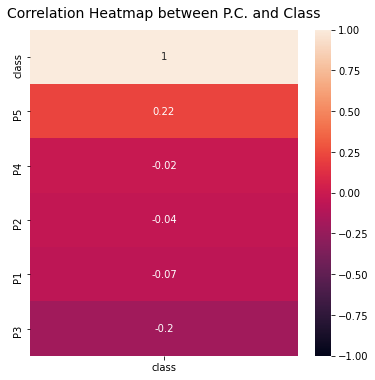

```python
pca_df = X_train_pca
pca_df['class'] = y_train
plt.figure(figsize=(6, 6))
sns.heatmap(round(pca_df.corr()[['class']].sort_values(by='class', ascending=False),2),
            annot=True, vmin=-1).set_title('Correlation Heatmap between P.C. and Class', fontdict={'fontsize':14}, pad=12)
```

The principal components removed the issue of multicollinearity between input variables, but they also have low correlation with the output classes which is to be expected since the original variables also showed little support of a linear relationship with the response.

# User-Defined Functions

Although standardization and principal component analysis were already performed in previous steps, **the use of a pipeline will ensure that the scoring metrics calculated during cross validation will be as accurate as possible**. If the standardized and PCA transformed dataframe is used as the input data for cross validation, the transform will have been calculated using the entire dataframe instead of each k-folds training set which could result in data leakage and incorrect scoring metric values. Since this will be done several times over all the candidate models, the use of user-defined functions will make this much easier to perform.

### `CV_Results`

This function uses a pipeline which standardizes the input data, transforms it using principal component analysis, and performs stratified cross validation on several different metrics to evaluate the suitability of multiple different models for classification. This function returns a dataframe with each row corresponding to a different model and each columns corresponding to a different scoring metric. A pipeline must be used in order to ensure that for each fold in the cross validation set, the training set is the set of data that is being used to determine the standardization and principal component transforms while the testing set is the seperate set of data that is only being transformed using the values calculated on the training set. This leads to more robust and accurate scoring metrics being calculated.

- **x**: The dependent variables or input
- **y**: The independent variables or target
- **model**: An array of classification models to be evaluated
- **pc**: The number of principal components to retain while performing PCA
- **cv**: The number of stratified folds to be evaluated during cross validation

### `Test_Results`

This function uses a pipeline which standardizes the training input data, transforms it using principal component analysis techniques, fits the selected classification models, and measures the classification capabilites for each given model on the testing data by calculating several scoring metrics. This is similar to the earlier function **`CV_Results`**, but instead of performing cross validation it evaluates the performance of the model on the withheld testing data for the final results.

- **X_train**: Training dataset dependent variables
- **X_test**: Testing dataset dependent variables
- **y_train**: Training dataset independent variables
- **y_test**: Testing dataset independent variables
- **model**: Array of classification models to be evaluated
- **pc**: The number of principal components to retain while performing PCA

```python
def CV_Results(x, y, model, pc, cv):

    #Set up dataframe that will be returned with corresponding column names
    display = pd.DataFrame(columns=['Model','Balanced Accuracy','Macro-precision','Macro_Recall',
                                    'Macro_F1','Fit Time','Prediction Time'])

    #Iterate cross validation scoring metrics for each model
    for i in model:
        scaler = StandardScaler()       #Standardization Step
        pca = PCA(n_components=pc)      #Principal Component Analysis step
        pipe = Pipeline(steps=[('scaler',scaler), ('pca',pca), ('model',i)]) #Set up pipeline including standardization and PCA
        skf = StratifiedKFold(n_splits=cv, shuffle=True, random_state=2022)  #Set up stratified k-folds for cross validation

        #Perform stratified cross validation using pipeline to calculate scoring metrics
        crvl = cross_validate(pipe, x, y, cv=skf, scoring=['balanced_accuracy','precision_macro','recall_macro','f1_macro'])

        #Gather model name and metrics to added to dataframe
        model    = type(i).__name__
        accuracy = round(crvl['test_balanced_accuracy'].mean(),4)
        mac_prec = round(crvl['test_precision_macro'].mean(),4)
        mac_rec  = round(crvl['test_recall_macro'].mean(),4)
        mac_f1   = round(crvl['test_f1_macro'].mean(),4)
        fit_time = round(crvl['fit_time'].mean(),4)
        pred_time= round(crvl['score_time'].mean(),4)

        model_metrics = [model, accuracy, mac_prec, mac_rec, mac_f1, fit_time, pred_time]

        #Add model metrics to returned dataframe
        display.loc[len(display)] = model_metrics
    #Remove index numbers for presentation
    display.index = ['']*len(display)

    return(display)
```

```python
def Test_Results(X_train, X_test, y_train, y_test, model, pc):

    #Set up dataframe that will be returned with corresponding column names
    display = pd.DataFrame(columns=['Model','Balanced Accuracy','Macro-precision','Macro-recall',
                                    'Macro-F1','Fit Time','Prediction Time'])

    #Iterate cross validation scoring metrics for each model
    for i in model:
        scaler = StandardScaler()   #Standardization Step
        pca = PCA(n_components=pc)  #Principal Component Analysis Step
        pipe = Pipeline(steps=[('scaler',scaler), ('pca',pca), ('model',i)])  #Set up pipeline including standardization and PCA
        #Calculate fit time
        start = time()
        pipe.fit(X_train,y_train)
        end = time()
        fit_time = round(end-start,4)
        #Calculate prediction time
        start = time()
        predicted = pipe.predict(X_test)
        end = time()
        pred_time = round(end-start,4)
        #Gather model name and final scoring metrics to be added to dataframe
        model    = type(i).__name__
        balanced_accuracy = round(balanced_accuracy_score(y_test,predicted),4)
        precision = round(precision_score(y_test,predicted,average='macro'),4)
        recall = round(recall_score(y_test,predicted,average='macro'),4)
        f1 = round(f1_score(y_test,predicted,average='macro'),4)

        model_metrics = [model,balanced_accuracy,precision,recall,f1,fit_time,pred_time]
        #Add model final metrics to returned dataframe
        display.loc[len(display)] = model_metrics
    #Remove index numbers for presentation
    display.index = ['']*len(display)

    return(display)
```

# Classification Modeling

There are several different modeling procedures that can be used for classification which each have their own strengths and weaknesses. When determining appropriate models to try, it is important to highlight key characteristics of the data that may have an effect on which models would work better than others.

> **Key Characteristics of the Data:**
> - The response variable has **highly imbalanced classes**
> - The **dataset is very large** with about 100,000 instances
> - The input **variables were transformed using principal component analysis** which may introduce information loss
> - The **principal components have low correlation values with the response variable** so linearity assumptions may not hold

With these features in mind, **five baseline models have been selected** as a starting point for determining a final classification model.

## Baseline Models

### `Logistic Regression`

Logistic regression is a parametric supervised learning algorithm that is commonly used for classification. This statistical model is an example of a generalized linear model that uses the logit function as a link function to measure the log-odds of a given event thereby measuring the probability of a given outcome occurring. It uses maximum likelihood estimation and typically another iterative process, such as Newton's method, to estimate regression coefficients which provide an interpretable metric of each predictor variable's contribution to the overall probability of the outcome event.

> **Advantages:**  
> Easily interpretable coefficients, quick prediction speeds, handles multinomial classification, straightforward and efficient model training  
> **Disadvantages:**  
> Affected by multicollinearity, dependent variables must be linearly related to the log-odds, linear decision surface limits classification capabilities

### `K-Nearest Neighbors`

The k-nearest neighbors algorithm is a non-parametric supervised learning algorithm which can handle both classification and regression. This methodology stores all the feature vectors along with their corresponding outcome classes and performs prediction of a new input by comparing it to the closest *k* neighbors, typically determined from its Euclidean distance, before using a basic majority vote to determine the correct class. Due to it approach, k-nearest neighbors is referred to as a "lazy learning" since no real training happens other than retaining the feature vectors.

> **Advantages:**  
> No training period, can be calculated using various distance metrics, flexible to different types of data relationships (linear or non-linear)  
> **Disadvantages:**  
> Difficultly with large datasets or datasets with many features due to the number of distance calculations required, sensitive to noisy data

### `Support Vector Machine`

Another group of non-parametric supervised learning models are support vector machines. Support vector machines identify hyperplanes that maximize the distance of the hyperplane from the nearest point of differing classes creating a region. Using various different kernels, these hyperplanes can be linear or non-linear depending on what best divides the dataset into separate class regions. Support vector machines must use the training data to find an appropriate hyperplane from all the different instances and kernels, but once the hyperplane is identified prediction is usually much quicker since it just comes down to which class region the new data points fall under.

> **Advantages:**  
> Works well in higher dimensions, kernels provide flexibility to data structures, memory efficient by only needing the final hyperplane  
> **Disadvantages:**  
> Costly for large datasets, many hyperparameters to optimize, susceptible to overfitting and noisy data, low interpretability

### `Random Forest`

Random Forests are an ensemble supervised learning method which work by using a collection of decision trees whose results are aggregated into a the final output. Using bootstrap samples and random selections of the features, a *forest* of decision trees are generated and trained that will work as a collective to process new data and determine a final output, typically using the majority vote for classification or averages for regression. Since each tree is trained with a slightly different bootstrap sample and with slightly different input features, random forests can be robust and work well to prevent overfitting.

> **Advantages:**  
> Prevents overfitting, less susceptible to outliers, able to handle large and high dimensional datasets, able to handle missing values  
> **Disadvantages:**  
> Provide feature importance but not entirely interpretable, many hyperparameters to optimize, better results require more decision trees be trained

### `Extreme Gradient Boosting`

Gradient boosting is another form of ensemble learning where a weak learner, typically a decision tree, is trained, evaluated, and retrained using the results of the previous step to try and improve the model further by continually learning from its mistakes. Extreme gradient boosting is a variation of this where the objective function is regularized in order to further improve the outcome by working to prevent overfitting. As opposed to a random forest where a collection of decision trees are all fitted and aggregated for a final result, extreme gradient boosting creates one decision tree at a time and improves upon it to hopefully result in a single, more accurate, model.

> **Advantages:**  
> Typically result in highly accuracy prediction, handle missing data, no pre-processing of the data is required, able to handle large and high dimensional datasets  
> **Disadvantages:**  
> Susceptible to outliers, continual boosting can lead to overfitting, many hyperparameter to optimize, may need to build many trees to converge

## Validation Metrics

To compare the different classification models, various metrics will be used to determine the overall performace of each model as well as their performances in comparison to one another. Choosing the correct metrics requires determining what the overall end goal should be whether that is computational speed, overall accuracy, or some other aspect.

In this case, the goal is to build a classification model that is as accurate as possible by classifying all three response classes accurately and reducing the number of incorrect classifications.

Since the classes are highly imbalanced but are deemed equally as important to identify correctly, **macro-average metrics of precision, recall and f1-score will be used so that each class is weighed equally as important**. Also due to the imbalanced class sizes found in the data, a balanced accuracy score will be calculated for comparison. Although less important to the goal of having as accurate a model as possible, the fit times and prediction times will also be compared to give a more in-depth look as to the performance of each model.

## Cross Validation: Baseline Models

Using a user-defined function, stratified cross-validation is performed to evaluate the scoring metrics and formulated into a table.

Recall that this function uses a pipeline to perform standardization and PCA within each k-fold in order to better reflect the true classification capabilities under the given scoring metrics.

```python
clf_lg = LogisticRegression(multi_class='multinomial', solver='newton-cg', random_state=2022)
clf_knn = KNeighborsClassifier()
clf_svc = svm.SVC(random_state=2022)
clf_rf = RandomForestClassifier(random_state=2022)
clf_xgb = XGBClassifier(random_state=2022)

CV_Results(x=X_train, y=y_train, model=[clf_lg, clf_knn, clf_svc, clf_rf, clf_xgb], pc=5, cv=5)
```

|  | Model | Balanced Accuracy | Macro-precision | Macro_Recall | Macro_F1 | Fit Time | Prediction Time |
| --- | --- | --- | --- | --- | --- | --- | --- |
|  | LogisticRegression | 0.7810 | 0.8370 | 0.7810 | 0.8035 | 1.5857 | 0.0281 |
|  | KNeighborsClassifier | 0.8966 | 0.9180 | 0.8966 | 0.9068 | 0.3031 | 0.7975 |
|  | SVC | 0.8709 | 0.8995 | 0.8709 | 0.8843 | 81.4272 | 34.1705 |
|  | RandomForestClassifier | 0.9091 | 0.9246 | 0.9091 | 0.9166 | 17.2549 | 0.3907 |
|  | XGBClassifier | 0.8959 | 0.9149 | 0.8959 | 0.9050 | 25.9502 | 0.1094 |

From the table above, the baseline models that have seemed to have the best overall perforance ignoring the fit and prediction times seem to be the random forest, extreme gradient boosting, and k-nearest neighbors models. The support vector classifer also does approximately as well as the top three models, but has a fit time and prediction time that far exceeds any of the other base models combined. Although logistic regression has one of the fasted fit and prediction times, it has the lowest remaining metrics possibly due a non-linear relationship to the logit function or class imbalance.

From these resutls, the three best models will have their hyperparameters tuned in order to see if they can be further improved using a grid search as well as Bayesian optimization to find the best values.

## Hyperparameter Tuning

```python
#KNN Hyperparameter Tuning: Grid Search Optimization
skf = StratifiedKFold(n_splits=5)

hyperparameters = {'clf_knn__n_neighbors':range(5,16),
                   'clf_knn__weights':['uniform','distance'],
                   'clf_knn__p':[1,2]}

pipe = Pipeline(steps=[('scaler',scaler), ('pca',pca), ('clf_knn',clf_knn)])

opt = GridSearchCV(pipe, hyperparameters, cv=skf, scoring='f1_macro')
opt.fit(X_train,y_train)
opt.best_params_
```

```
{'clf_knn__n_neighbors': 6, 'clf_knn__p': 2, 'clf_knn__weights': 'distance'}
```

```python
#Warnings will be removed since BayesSearchCV raises them if it returns to a possible maximum
warnings.filterwarnings("ignore")
```

```python
#Random Forest Hyperparameter Tuning: Baysian Optimization
pipe = Pipeline(steps=[('scaler',scaler), ('pca',pca), ('clf_rf',clf_rf)])

hyperparameters = {'clf_rf__n_estimators':Integer(75,125,prior='uniform'),
                   'clf_rf__criterion':Categorical(['gini','entropy','log_loss']),
                   'clf_rf__max_features':Categorical(['sqrt','log2',None]),
                   'clf_rf__max_samples':Real(0.33,.95,prior='uniform')}

opt = BayesSearchCV(pipe, hyperparameters,scoring='f1_macro', cv=skf, random_state=2022)
opt.fit(X_train,y_train)
opt.best_params_
```

```
OrderedDict([('clf_rf__criterion', 'log_loss'),
             ('clf_rf__max_features', 'sqrt'),
             ('clf_rf__max_samples', 0.95),
             ('clf_rf__n_estimators', 111)])
```

```python
#XGBoost Hyperparameter Tunning: Baysian Optimization
clf_xgb = XGBClassifier(random_state=2022)
pipe = Pipeline(steps=[('scaler',scaler), ('pca',pca), ('clf_xgb',clf_xgb)])

hp = {'clf_xgb__learning_rate':Real(0.1,1,prior='uniform'),
      'clf_xgb__subsample':Real(0.5,1,prior='uniform'),
      'clf_xgb__n_estimators':Integer(75,125,prior='uniform'),
      'clf_xgb__lambda':Real(1,100,prior='uniform'),
      'clf_xgb__gamma':Real(0.1,50,prior='uniform')}

opt = BayesSearchCV(pipe, hp, cv=skf, scoring='f1_macro', random_state=2022)
opt.fit(X_train,y_train)
opt.best_params_
```

```
OrderedDict([('clf_xgb__gamma', 0.1),
             ('clf_xgb__lambda', 96.12834237628631),
             ('clf_xgb__learning_rate', 0.883876746447124),
             ('clf_xgb__n_estimators', 125),
             ('clf_xgb__subsample', 0.7300115278483512)])
```

## Cross Validation: Tuned Hyperparameters

```python
clf_knn = KNeighborsClassifier(n_neighbors=6, p=2, weights='distance')
clf_rf = RandomForestClassifier(n_estimators=111, criterion='log_loss', max_features='sqrt', max_samples=.95, random_state=2022)
clf_xgb = XGBClassifier(subsample=0.73, n_estimators=125, learning_rate=0.88, reg_lambda=96.13, gamma=0.1, random_state=2022)

CV_Results(x=X_train, y=y_train, model=[clf_knn, clf_rf, clf_xgb], pc=5, cv=5)
```

|  | Model | Balanced Accuracy | Macro-precision | Macro_Recall | Macro_F1 | Fit Time | Prediction Time |
| --- | --- | --- | --- | --- | --- | --- | --- |
|  | KNeighborsClassifier | 0.9000 | 0.9218 | 0.9000 | 0.9104 | 0.2978 | 0.3532 |
|  | RandomForestClassifier | 0.9097 | 0.9256 | 0.9097 | 0.9173 | 29.3191 | 0.4000 |
|  | XGBClassifier | 0.9067 | 0.9205 | 0.9067 | 0.9133 | 30.0089 | 0.1250 |

## Final Models

With the selected models having been improved, a user-defined function `Test_Results` will generate the final metric results for each of the tuned classifiers.

```python
clf_knn = KNeighborsClassifier(n_neighbors=6, p=2, weights='distance')
clf_rf = RandomForestClassifier(n_estimators=111, criterion='log_loss', max_features='sqrt', max_samples=.95, random_state=2022)
clf_xgb = XGBClassifier(subsample=0.73, n_estimators=125, learning_rate=0.88, reg_lambda=96.13, gamma=0.1, random_state=2022)

Test_Results(X_train, X_test, y_train, y_test, model=[clf_knn, clf_rf, clf_xgb], pc=5)
```

|  | Model | Balanced Accuracy | Macro-precision | Macro-recall | Macro-F1 | Fit Time | Prediction Time |
| --- | --- | --- | --- | --- | --- | --- | --- |
|  | KNeighborsClassifier | 0.9031 | 0.9223 | 0.9031 | 0.9122 | 0.3831 | 0.4531 |
|  | RandomForestClassifier | 0.9107 | 0.9273 | 0.9107 | 0.9186 | 37.4383 | 0.4843 |
|  | XGBClassifier | 0.9085 | 0.9202 | 0.9085 | 0.9141 | 37.7720 | 0.0937 |

# Summary and Reflection

All three final models have approximently equivalent scoring metrics accounting for the overall classificiation performance, but **the random forest model is the best by a margin of less than 1% across all scoring metrics**.

One possible way to improve these models would be to use a **resampling technique to better balance the three response class sizes**. Some classification models such as logistic regression tend to perform better when there is more of a balance between the various classes. Since the dataset is rather large and contains thousands of instances from all the class, an **undersampling** technique such as condensed nearest neighbors, editted nearest neighbors, or even a combination of the two could also help to balance the difference in class sizes. These will strategically removing majority class instances that are misclassified based on its nearest neighbors thereby using a smaller portion of the data which will result in shorter fit and prediction times. Another idea could be to **combine an undersampling and oversampling technique such as SMOTE-Tomek Links** which would generate new artificial data points from the minority class while also removing borderline instances that may be misclassified based on its neighboring data points. Although this method may increase the overall size of the dataset, it could improve the overall classification capabilites by completely balancing the class sizes given prediction and fit times were of less importance to overall performance.

Since the three final models were flexible in regards to the relationship between the inputs and the output, **another possibility to improve the results could be to remove performing principal component analysis** from the pipeline. By removing this, there would be less of an information loss from the original variables to those used in the final modeling process which may work to improve classification capabilities.

A final suggestion would be to **use a more powerful classification methodology such as an artificial neural network** to handle this particular dataset. Although they offer less insight into the direct relation between specific inputs and their contribution to the classification process, artificial neural networks can handle much larger datasets with very little configuration adjustments which may be a good option if the overall goal is classification performance rather than identifying input-output relationship.